# Analyse et exploration de données de maladies cardiaques

Ce jeu de données se penche sur les maladies cardiaques et comprends plusieurs variables en rapport avec cette thématique. La database contenait initialement 76 variables, mais le jeu de données publié lui n’en contient au final que 14.  
Les variables sont, par ordre d’apparition:  
1. Age.  
2. Sexe.  
3. Type de douleur thoracique.  
4. Tension au repos.  
5. Cholesterol sanguin (en mg/dl).  
6. Glycémie à jeun (> 120 mg/dl).  
7. Résultat de l’ECG au repos.  
8. Fréquence cardiaque maximum.  
9. Angine induite à l’effort.  
10. Depression du ST induit par l’exercise relativement au repos.  
11. Pente du segment ST au pic de l’exercice.  
12. Nombre de vaisseaux majeurs coloriés par fluroscopie.  
13. Etat de la thalassémie.  
14. Diagnostic de thrombose coronaire.  
15. Classe d’age, par tranches de 10 ans.

On va donc s’intéresser aux caractéristiques des différents groupes de patients, et chercher à comprendre comment ces caractéristiques influent sur l’apparition des maladies cardiovasculaires.

#### Chargement des librairies

```r
library(readr)
library(plyr)
library(arules)
library(tidyverse)
```

# I) Chargement des données

```r
data <- read_csv("heart.csv")
```

#### A) Nettoyage des données

```r
data$sex = as.factor(data$sex)
data$sex = revalue(data$sex, c("1"="M", "0"="F"))
data$fbs = as.factor (data$fbs)
data$fbs = revalue(data$fbs, c("1"="> 120 mg/dl", "0"="<= 120 mg/dl"))
data$exang = as.logical(data$exang)
colnames(data)[colnames(data)=="exang"] <- "ex_angina"
data$age_class = discretize(data$age, method = "fixed", breaks = 7, categories = c(20,30,40,50,60,70,80))
data$cp = as.factor(data$cp)
data$cp = revalue(data$cp, c("1" = "typical angina", "2" = "atypical angina", "3" = "non-anginal pain", "0" = "asymptomatic"))
colnames(data)[colnames(data)=="cp"] <- "chest_pain"
colnames(data)[colnames(data)=="trestbps"] <- "resting_bp"
data$restecg = as.factor(data$restecg)
data$restecg = revalue(data$restecg, c("0"="normal", "1"="ST-T wave abnormality", "2"="left ventricular hypertrophy"))
colnames(data)[colnames(data)=="restecg"] <- "resting_ecg"
colnames(data)[colnames(data)=="thalach"] <- "max_bpm"
colnames(data)[colnames(data)=="oldpeak"] <- "st_depression"
data$ca = as.factor(data$ca)
colnames(data)[colnames(data)=="ca"] <- "colorised_vessels"
data$thal = as.factor(data$thal)
colnames(data)[colnames(data)=="thal"] <- "thal"
data$slope = as.factor(data$slope)
data$slope = revalue(data$slope, c("0"="upsloping", "1"="flat", "2"="downsloping"))
colnames(data)[colnames(data)=="slop"] <- "st_slope"
data$target = as.logical(data$target)
colnames(data)[colnames(data)=="target"] <- "angiographic_disease"
data$thal = as.factor(data$thal)
data$thal = revalue(data$thal, c("0"="unknown", "1"="normal", "2"="fixed defect", "3"="reversable defect"))
colnames(data)[colnames(data)=="thal"] <- "thalassemia"
```

#### B) Aperçu du jeu de données

```r
head(data)
```

| age | sex | chest_pain | resting_bp | chol | fbs | resting_ecg | max_bpm | ex_angina | st_depression | slope | colorised_vessels | thalassemia | angiographic_disease | age_class |
| --- | --- | --- | --- | --- | --- | --- | --- | --- | --- | --- | --- | --- | --- | --- |
| 63 | M | non-anginal pain | 145 | 233 | > 120 mg/dl | normal | 150 | FALSE | 2.3 | upsloping | 0 | normal | TRUE | [60,70) |
| 37 | M | atypical angina | 130 | 250 | <= 120 mg/dl | ST-T wave abnormality | 187 | FALSE | 3.5 | upsloping | 0 | fixed defect | TRUE | [30,40) |
| 41 | F | typical angina | 130 | 204 | <= 120 mg/dl | normal | 172 | FALSE | 1.4 | downsloping | 0 | fixed defect | TRUE | [40,50) |
| 56 | M | typical angina | 120 | 236 | <= 120 mg/dl | ST-T wave abnormality | 178 | FALSE | 0.8 | downsloping | 0 | fixed defect | TRUE | [50,60) |
| 57 | F | asymptomatic | 120 | 354 | <= 120 mg/dl | ST-T wave abnormality | 163 | TRUE | 0.6 | downsloping | 0 | fixed defect | TRUE | [50,60) |
| 57 | M | asymptomatic | 140 | 192 | <= 120 mg/dl | ST-T wave abnormality | 148 | FALSE | 0.4 | flat | 0 | normal | TRUE | [50,60) |

#### C) Résumé des données et leur réparttion

```r
summary(data)
```

```
      age        sex                chest_pain    resting_bp
 Min.   :29.00   F: 96   asymptomatic    :143   Min.   : 94.0
 1st Qu.:47.50   M:207   typical angina  : 50   1st Qu.:120.0
 Median :55.00           atypical angina : 87   Median :130.0
 Mean   :54.37           non-anginal pain: 23   Mean   :131.6
 3rd Qu.:61.00                                  3rd Qu.:140.0
 Max.   :77.00                                  Max.   :200.0
      chol                 fbs
 Min.   :126.0   <= 120 mg/dl:258
 1st Qu.:211.0   > 120 mg/dl : 45
 Median :240.0
 Mean   :246.3
 3rd Qu.:274.5
 Max.   :564.0
                       resting_ecg     max_bpm      ex_angina
 normal                      :147   Min.   : 71.0   Mode :logical
 ST-T wave abnormality       :152   1st Qu.:133.5   FALSE:204
 left ventricular hypertrophy:  4   Median :153.0   TRUE :99
                                    Mean   :149.6
                                    3rd Qu.:166.0
                                    Max.   :202.0
 st_depression          slope     colorised_vessels
 Min.   :0.00   upsloping  : 21   0:175
 1st Qu.:0.00   flat       :140   1: 65
 Median :0.80   downsloping:142   2: 38
 Mean   :1.04                     3: 20
 3rd Qu.:1.60                     4:  5
 Max.   :6.20
            thalassemia  angiographic_disease   age_class
 unknown          :  2   Mode :logical        [20,30):  1
 normal           : 18   FALSE:138            [30,40): 15
 fixed defect     :166   TRUE :165            [40,50): 72
 reversable defect:117                        [50,60):125
                                              [60,70): 80
                                              [70,80]: 10
```

# II) Exploration du jeu de données

#### A) Analyse de la population de l’étude

Le jeu de donnees comporte 303 patients, dont 207 hommes et 96 femmes.

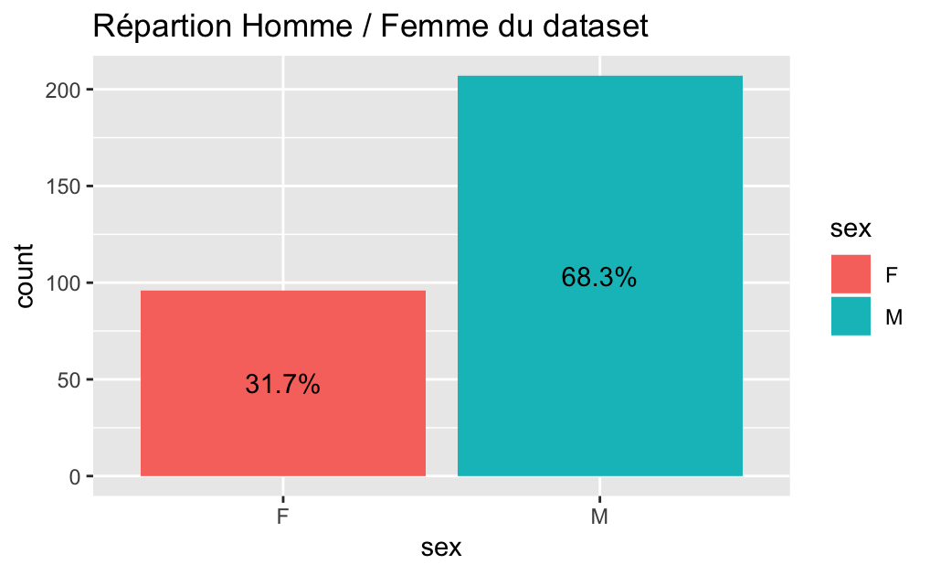

```r
ggplot(data = data)+
  geom_bar(aes(x = sex, fill = sex), position = "dodge")+
  geom_text(aes(x = sex, label = scales::percent(..count../sum(..count..))), stat="count",position=position_stack(0.5))+
  ggtitle("Répartion Homme / Femme du dataset")
```

La répartition des patients par tranche d’âge est la suivante:

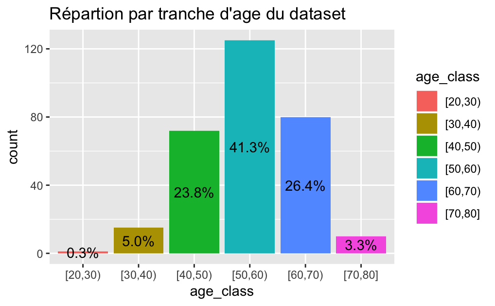

```r
ggplot(data = data)+
  geom_bar(aes(x = age_class, fill = age_class), position = "dodge")+
    geom_text(aes(x = age_class, label = scales::percent(..count../sum(..count..))), stat="count",position=position_stack(0.5))+
  ggtitle("Répartion par tranche d'age du dataset")
```

On remarque donc qu’on a 2 fois plus d’hommes que de femmes. Afin d’avoir des résultats interprétables il serait donc intéressant de travailler à partir de ratios ou de pourcentage pour chaque sexe. Enfin, plus de 90% des patients ont entre 30 et 70 ans. Il sera donc compliqué d’étendre nos résultats au delà de cette tranche d’âge.

#### B) Répartition des maladies cardiaques dans la population

[figure not shown]

Ainsi on peut remarquer que dans ce jeu de données les femmes ont un risque de diagnostic de thrombose coronaire positif supérieur de 30% par rapport aux hommes.

```r
ggplot(data = data)+
  geom_bar(aes(x= age_class, fill = angiographic_disease), position = "dodge")

ggplot(data = data)+
  geom_jitter(aes(x=age_class, y = sex, color = angiographic_disease))

Fcardiac <- 100*as.numeric(data %>% filter(angiographic_disease == TRUE,
                                       sex == "F") %>%
                         summarise(angiographic_disease = sum(angiographic_disease)))/96

Hcardiac <- 100*as.numeric(data %>% filter(angiographic_disease == TRUE,
                                       sex == "M") %>%
                         summarise(angiographic_disease = sum(angiographic_disease)))/96
```

[output not shown]

# Douleurs thoraciques en fonction de la maladie cardiaque